# Введение в Linux

## 3.4 Bash — вывод echo

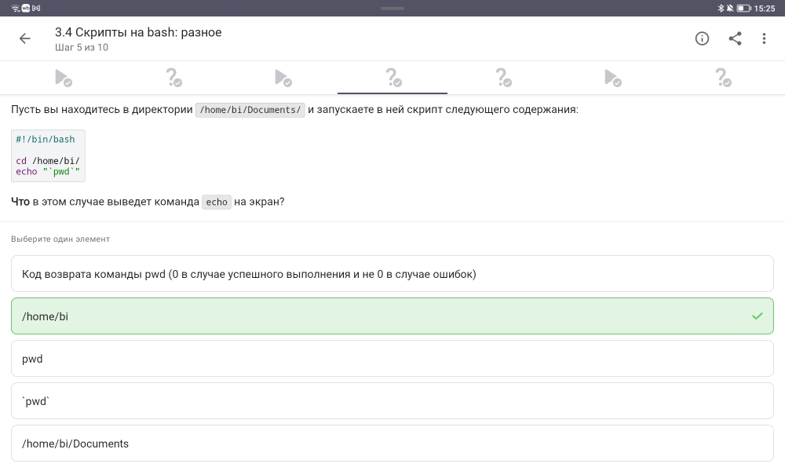

## Bash — кавычки и выполнение команд

```bash
echo "pwd"      # выведет строку "pwd"
echo $(pwd)     # выведет текущую директорию
echo `pwd`      # выведет текущую директорию
```

- Двойные кавычки не вызывают выполнение команды
- Для выполнения нужны `$()` или обратные кавычки

## 3.5 Поиск — find -name vs -iname

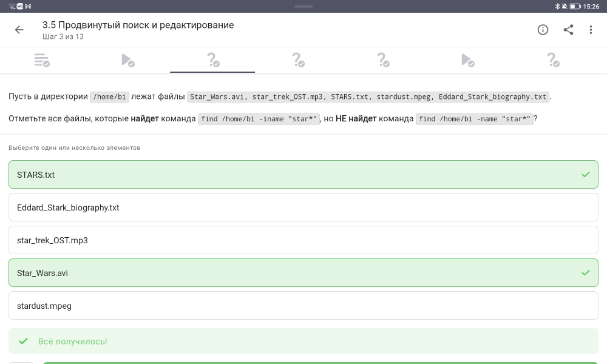

**Вопрос:** Какие файлы найдёт `-iname`, но не найдёт `-name`?

**Правильные ответы:** - `STARs.txt` - `Star_Wars.avi`

## find — регистрозависимость

| Опция | Регистр | Пример |
| --- | --- | --- |
| `-name "star*"` | Чувствительный | только `star...` |
| `-iname "star*"` | Нечувствительный | `star...`, `Star...`, `STAR...` |

- `-iname` находит все варианты написания

## 3.5 Поиск — find -path vs -name

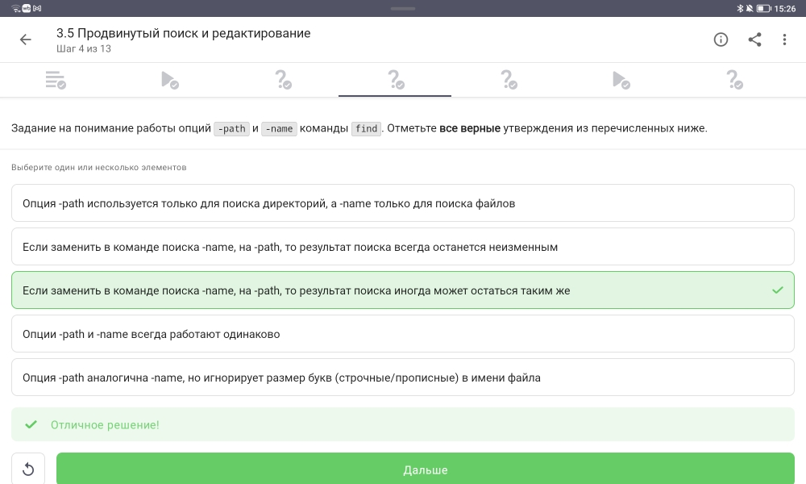

**Вопрос:** Верные утверждения о `-path` и `-name`

**Правильное утверждение:** - Если заменить `-name` на `-path`, результат иногда может остаться таким же

## find — -name vs -path

| Опция | Область поиска |
| --- | --- |
| `-name` | Только имя файла |
| `-path` | Полный путь к файлу |

- Результаты совпадают, когда шаблон находится только в имени файла

## 3.5 Поиск — find с mindepth/maxdepth

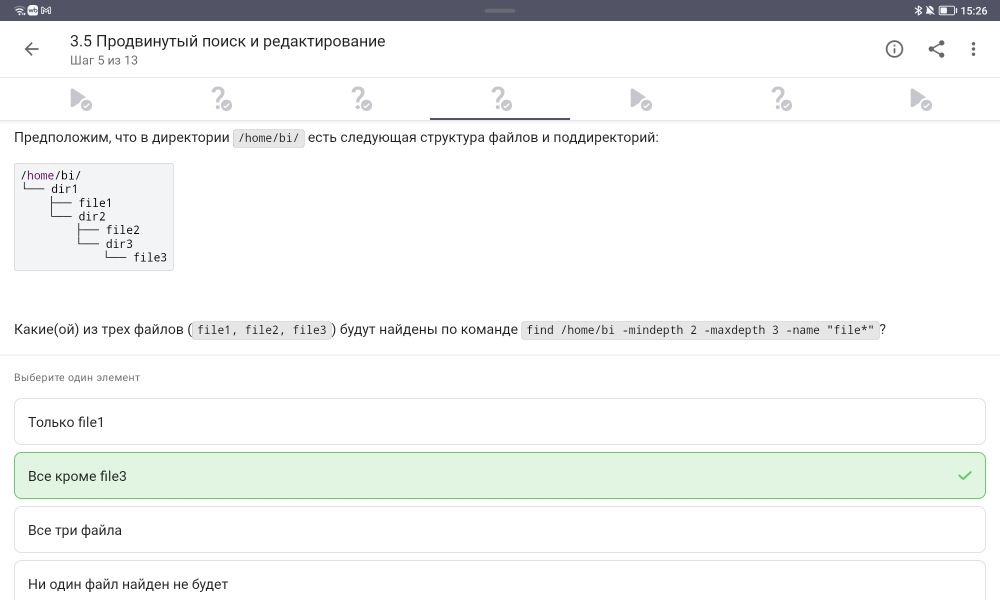

**Вопрос:** Какие файлы найдёт `find -mindepth 2 -maxdepth 3`?

## find — глубина поиска

[output not shown]

## 3.5 Поиск — grep -A, -B, -C

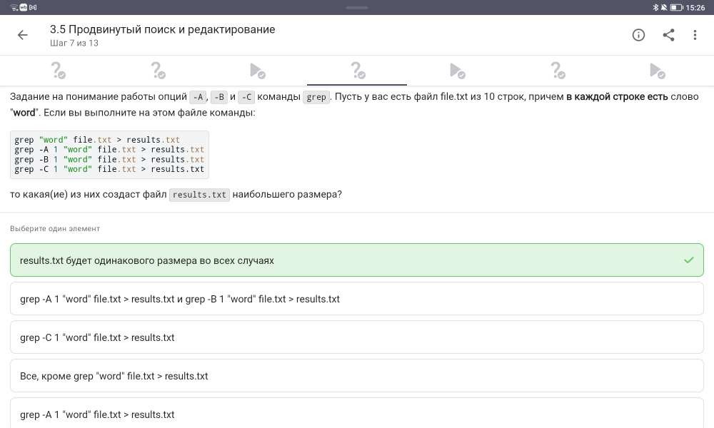

**Вопрос:** Какая команда создаст наибольший файл?

## grep — контекст

| Опция | Значение |
| --- | --- |
| `-A 1` | строка + 1 строка **после** |
| `-B 1` | строка + 1 строка **до** |
| `-C 1` | строка + 1 строка **до** + 1 строка **после** |

- При слове “word” в каждой строке, `-C 1` выводит **все** строки

## 3.5 Поиск — регулярные выражения grep

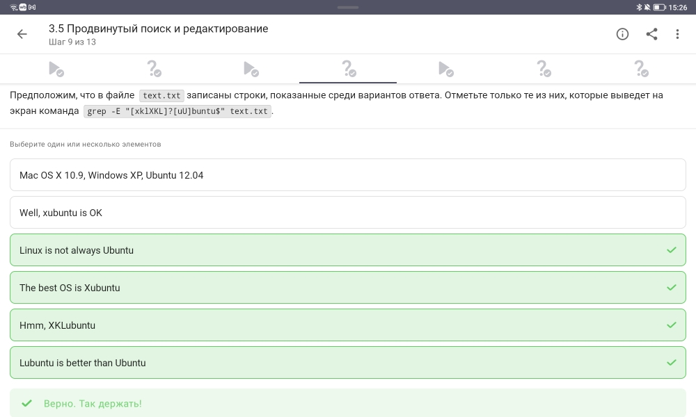

**Вопрос:** Какие строки выведет `grep -E "[xk1XKL]?[uU]buntu$"`?

## Регулярное выражение — разбор

```
[xk1XKL]?[uU]buntu$
```

| Часть | Значение |
| --- | --- |
| `[xk1XKL]?` | 0 или 1 символ из набора |
| `[uU]buntu` | ubuntu или Ubuntu |
| `$` | конец строки |

- Подходит: `Ubuntu`, `xubuntu`, `Xubuntu`, `Lubuntu`, `Kubuntu`

## 3.5 Поиск — sed без -n

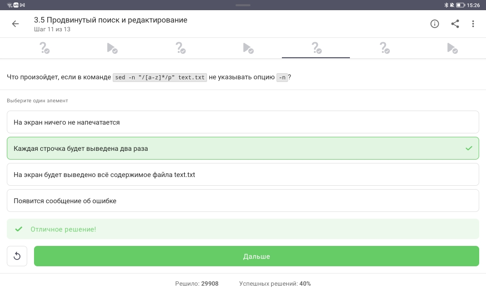

**Вопрос:** Что произойдёт без опции `-n`?

## sed — опция -n

| Режим | Поведение |
| --- | --- |
| Без `-n` | Автоматическая печать **всех** строк |
| С `-n` | Печать только по команде `p` |

## 3.6 Gnuplot — опция –persist

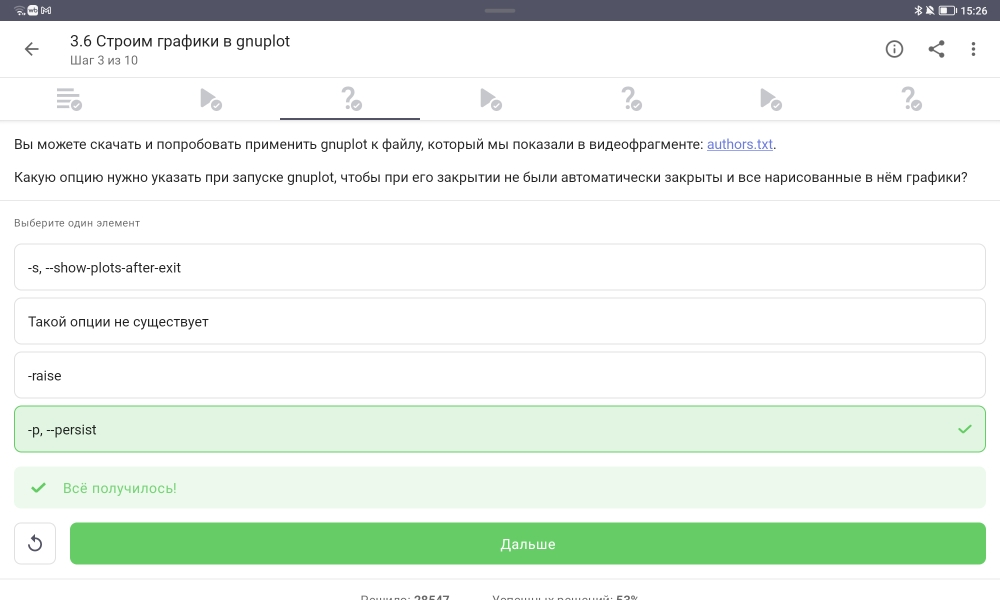

**Вопрос:** Как сохранить графики после закрытия gnuplot?

**Правильный ответ:** `-p, --persist`

## Gnuplot — persist

```bash
# График закроется вместе с gnuplot
gnuplot script.gp

# График останется открытым
gnuplot -p script.gp
gnuplot --persist script.gp
```

## 3.6 Gnuplot — autotitle columnhead

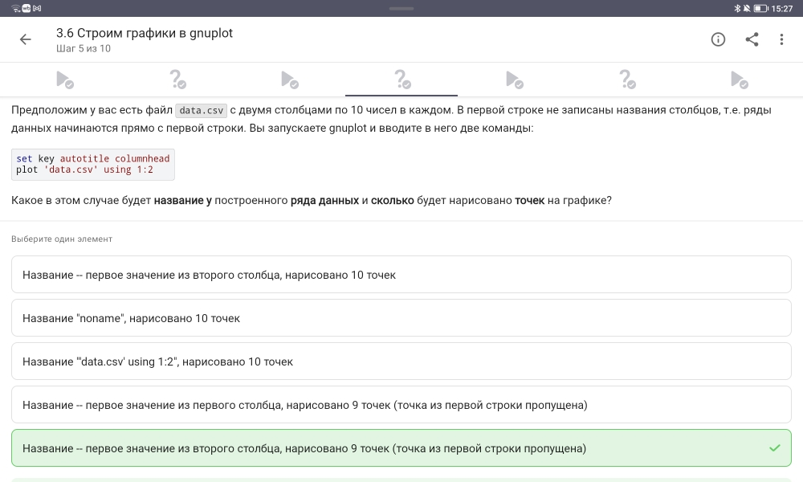

**Вопрос:** Название ряда и количество точек?

## Gnuplot — заголовки

```
set key autotitle columnhead
plot 'data.csv' using 1:2
```

## 3.6 Gnuplot — настройка меток

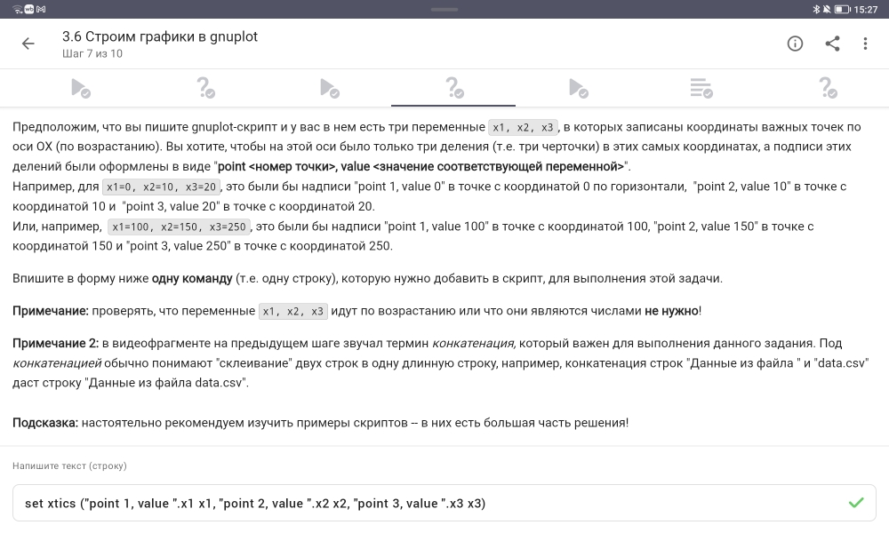

**Задание:** Установить метки на оси X в точках x1, x2, x3

**Правильный ответ:**

```
set xtics ("point 1, value ".x1 x1, "point 2, value ".x2 x2, "point 3, value ".x3 x3)
```

## Gnuplot — set xtics

- `"."` — конкатенация строк
- Значения переменных подставляются автоматически

## 3.6 Gnuplot — анимация

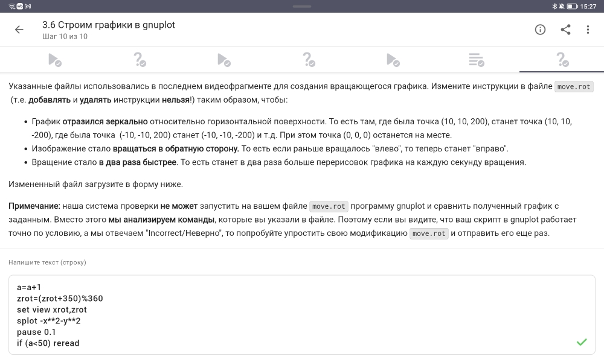

**Задание:** Изменить move.rot (отражение, обратное вращение, ускорение)

**Модифицированный код:**

[output not shown]

## Модификация анимации

[output not shown]

## 3.7 Разное — права доступа (chmod)

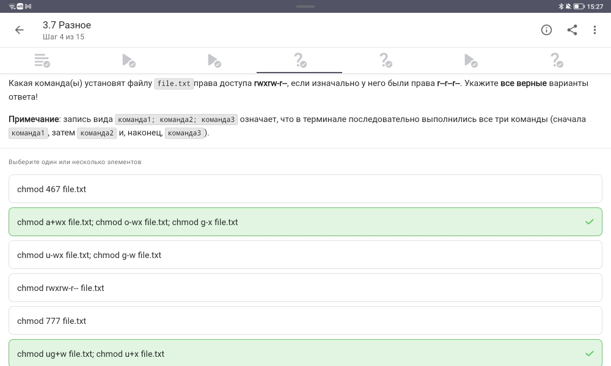

## chmod — права доступа

[output not shown]

## 3.7 Разное — команда wc

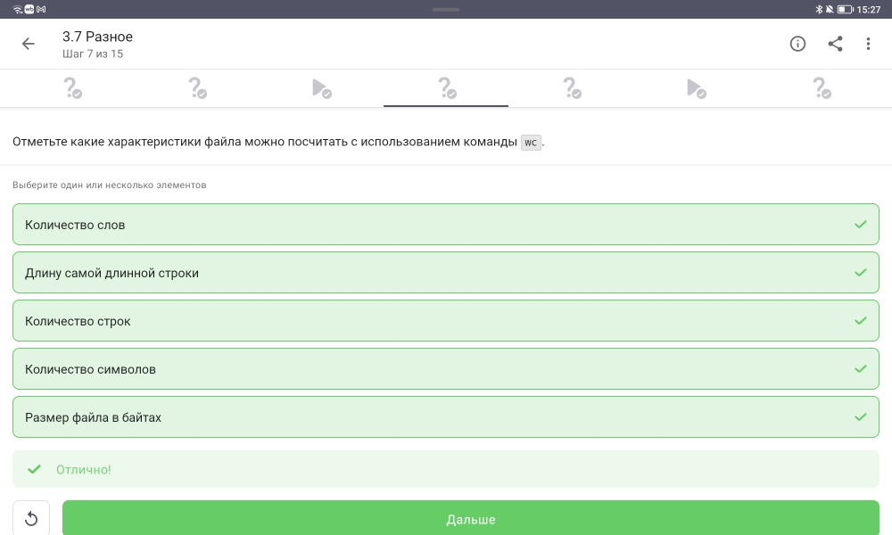

**Вопрос:** Какие характеристики можно посчитать wc?

**Правильные ответы:** все перечисленные

## wc — опции

```bash
wc -l file.txt    # количество строк
wc -w file.txt    # количество слов
wc -c file.txt    # количество байт
wc -m file.txt    # количество символов
wc -L file.txt    # длина самой длинной строки
```

## 3.7 Разное — размер директории (du)

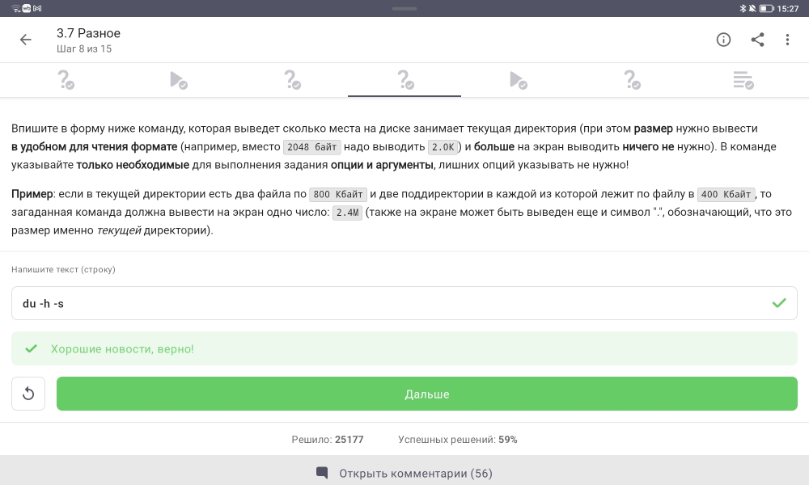

**Задание:** Вывести размер текущей директории

**Правильный ответ:** `du -h -s`

## du — опции

```bash
du -h -s
```

| Опция | Значение |
| --- | --- |
| `-h` | human-readable (K, M, G) |
| `-s` | summary (только общий размер) |

## 3.7 Разное — создание директорий

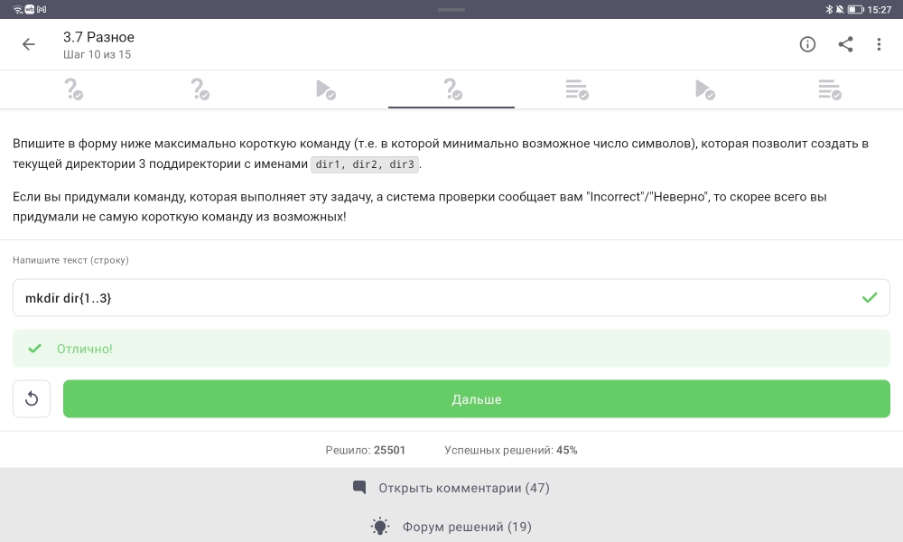

**Задание:** Самая короткая команда для создания dir1, dir2, dir3

**Правильный ответ:** `mkdir dir{1..3}`

## Brace expansion в bash

```bash
# Длинный вариант
mkdir dir1 dir2 dir3

# Короткий вариант (brace expansion)
mkdir dir{1..3}
```

- `{1..3}` раскрывается в `1 2 3`

# Результаты

## Итоги выполнения

- **Освоенные темы раздела 3:**
  - Текстовый редактор vim (навигация, редактирование, замена)
  - Bash-скрипты (переменные, циклы, условия, история)
  - Продвинутый поиск (find, grep, sed)
  - Визуализация данных (gnuplot)
  - Системные утилиты (chmod, wc, du, mkdir)

## Ключевые навыки

| Навык | Инструменты |
| --- | --- |
| Редактирование текста | vim (`:w`, `:q`, `:%s`, `w`, `W`, `d`, `y`, `p`) |
| Bash-скрипты | переменные, `for`, `if`, `continue` |
| Поиск файлов | `find -name`, `-iname`, `-path`, `-mindepth` |
| Поиск текста | `grep -E`, `-A`, `-B`, `-C`, `sed` |
| Визуализация | `gnuplot -p`, `set xtics` |
| Управление файлами | `chmod`, `wc`, `du -h -s`, `mkdir {1..3}` |

# Заключение

## Итоговый слайд

**Основные результаты третьего этапа:**

- Освоен текстовый редактор vim (навигация, редактирование, замена)
- Изучены bash-скрипты (переменные, циклы, условия)
- Приобретены навыки продвинутого поиска (find, grep, sed)
- Освоена визуализация данных в gnuplot
- Изучены системные утилиты (chmod, wc, du)

**Курс «Введение в Linux» успешно пройден!**